# Principal Component Analysis

Dataset evoc_table

This dataset contains 5 individuals and 84 variables.

### 1. Study of the outliers

The analysis of the graphs does not detect any outlier.

### 2. Inertia distribution

The inertia of the first dimensions shows if there are strong relationships between variables and suggests the number of dimensions that should be studied.

The first two dimensions of analyse express **78.15%** of the total dataset inertia ; that means that 78.15% of the individuals (or variables) cloud total variability is explained by the plane. This percentage is high and thus the first plane represents an important part of the data variability. This value is greater than the reference value that equals **61.73%**, the variability explained by this plane is thus significant (the reference value is the 0.95-quantile of the inertia percentages distribution obtained by simulating 15353 data tables of equivalent size on the basis of a normal distribution).

From these observations, it is probably not useful to interpret the next dimensions.

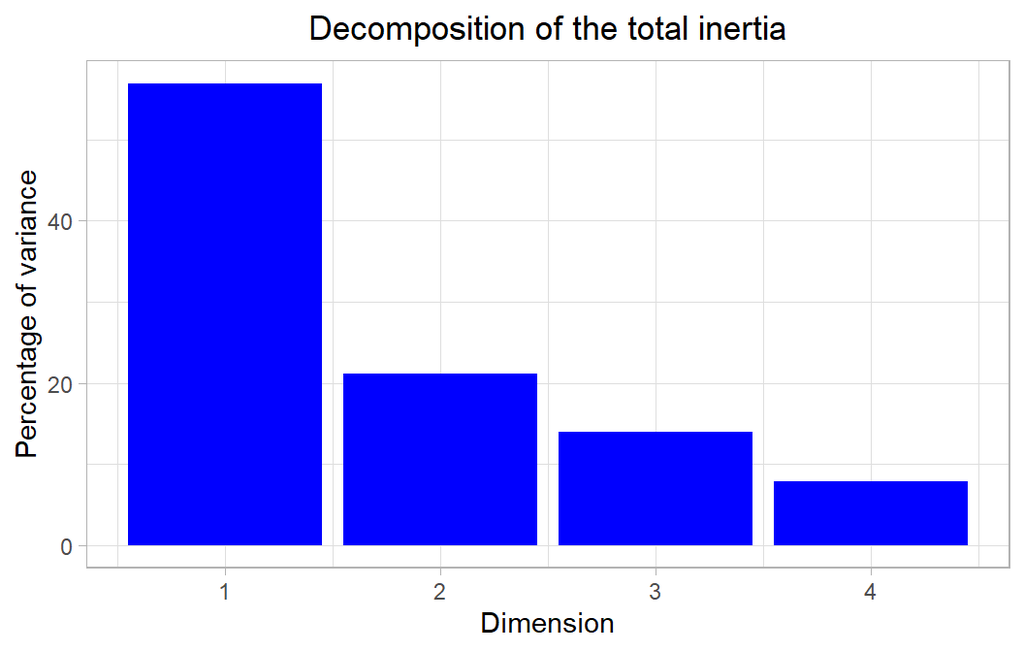

**Figure 2 - Decomposition of the total inertia** *The first factor is major: it expresses itself 56.99% of the data variability.* *Note that in such a case, the variability related to the other components might be meaningless, despite of a high percentage.*

An estimation of the right number of axis to interpret suggests to restrict the analysis to the description of the first 1 axis. These axis present an amount of inertia greater than those obtained by the 0.95-quantile of random distributions (56.99% against 34.81%). This observation suggests that only this axis is carrying a real information. As a consequence, the description will stand to these axis.

### 3. Description of the dimension 1

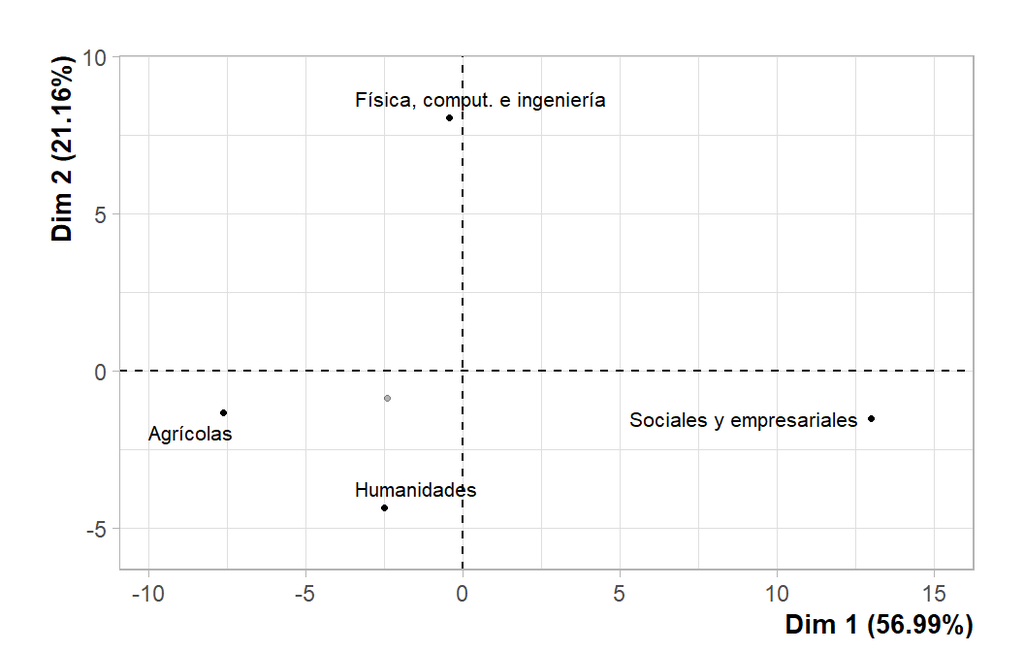

**Figure 3.1 - Individuals factor map (PCA)** *The labeled individuals are those with the higher contribution to the plane construction.*

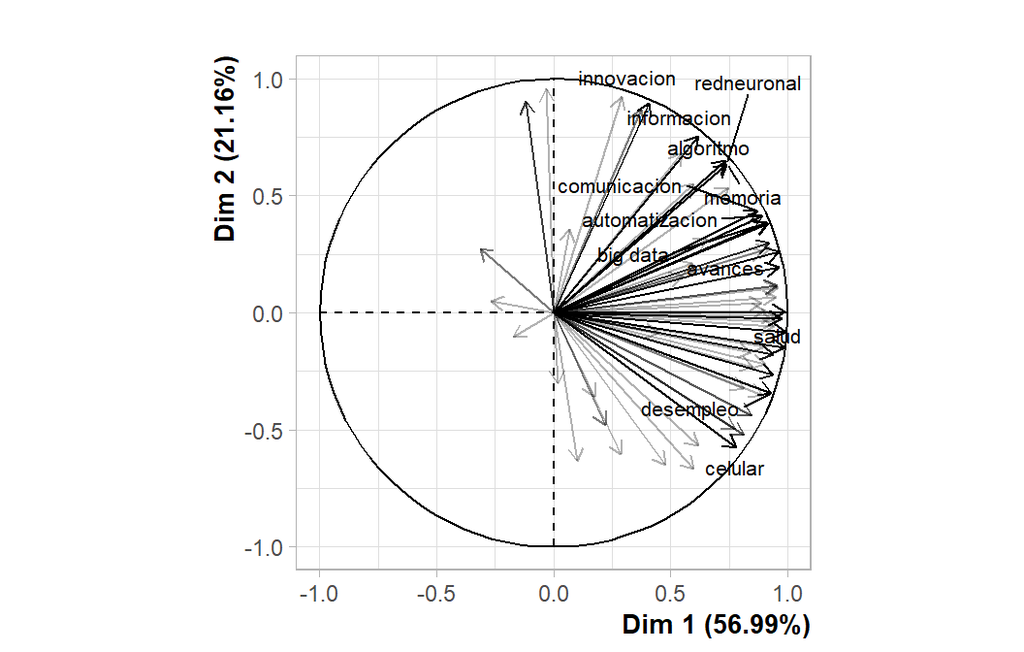

**Figure 3.2 - Variables factor map (PCA)** *The labeled variables are those the best shown on the plane.*

The **dimension 1** opposes individuals such as *Sociales y empresariales* (to the right of the graph, characterized by a strongly positive coordinate on the axis) to individuals such as *Agrícolas* and *Humanidades* (to the left of the graph, characterized by a strongly negative coordinate on the axis).

The group in which the individual *Sociales y empresariales* stands (characterized by a positive coordinate on the axis) is sharing :

- high values for the variables *vigilancia*, *terminator*, *productividad*, *cibernetica*, *basededato* and *ayuda* (variables are sorted from the strongest).

The group in which the individuals *Agrícolas* and *Humanidades* stand (characterized by a negative coordinate on the axis) is sharing :

- low values for the variables *memoria*, *redneuronal* and *informacion* (variables are sorted from the weakest).

### 4. Classification

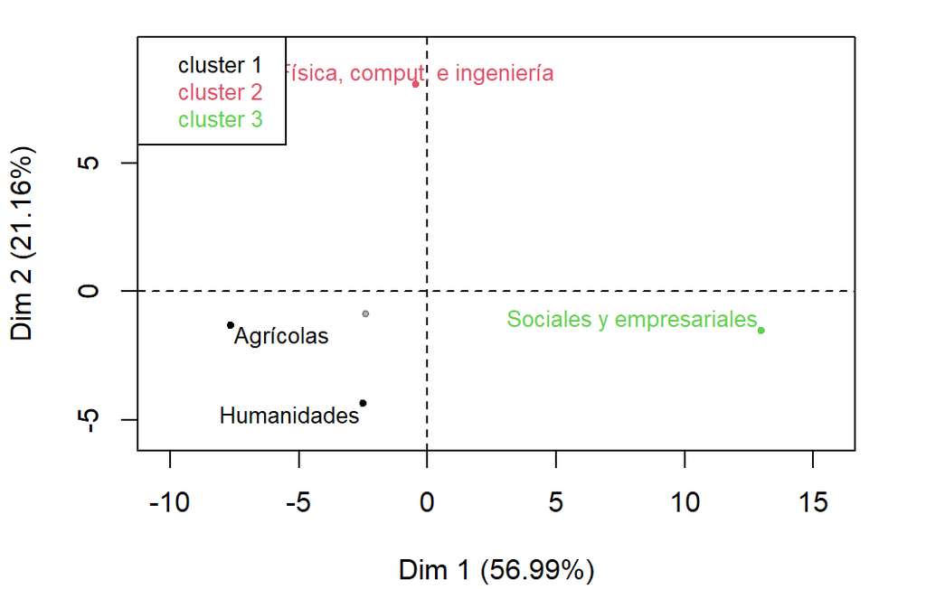

**Figure 4 - Ascending Hierarchical Classification of the individuals.** *The classification made on individuals reveals 3 clusters.*

The **cluster 1** is made of individuals such as *Agrícolas* and *Humanidades*. This group is characterized by :

- low values for the variables *memoria*, *redneuronal* and *informacion* (variables are sorted from the weakest).

The **cluster 2** is made of individuals such as *Física, comput. e ingeniería*. This group is characterized by :

- high values for the variable *matematica*.

The **cluster 3** is made of individuals such as *Sociales y empresariales*. This group is characterized by :

- high values for the variables *vigilancia*, *terminator*, *productividad*, *cibernetica*, *basededato* and *ayuda* (variables are sorted from the strongest).

## Annexes

```r
dimdesc(res, axes = 1:1)
```

```
$Dim.1

Link between the variable and the continuous variables (R-square)
=================================================================================
                 correlation      p.value
salud              0.9918166 0.0008875638
control            0.9895357 0.0012829605
robot              0.9879530 0.0015844095
avance             0.9732463 0.0052319093
tecnologia         0.9635580 0.0083051740
avances            0.9611186 0.0091494852
algoritr           0.9595609 0.0097025060
posibilidad        0.9532787 0.0120375825
manipulacion       0.9532787 0.0120375825
deshumanizacion    0.9532787 0.0120375825
incertidumbre      0.9506412 0.0130658757
futuro             0.9486310 0.0138678992
dato               0.9434745 0.0159949523
eficiencia         0.9427714 0.0162925760
internet           0.9398010 0.0175694024
vigilancia         0.9387921 0.0180101242
terminator         0.9387921 0.0180101242
productividad      0.9387921 0.0180101242
cibernetica        0.9387921 0.0180101242
basededato         0.9387921 0.0180101242
ayuda              0.9387921 0.0180101242
desempleo          0.9316311 0.0212381836
ciencia            0.9248489 0.0244500329
red                0.9229313 0.0253843097
internetdeelcosa   0.9229313 0.0253843097
inteligencia       0.9229313 0.0253843097
dependencia        0.9229313 0.0253843097
bigdata            0.9229313 0.0253843097
programacion       0.9177138 0.0279827017
big data           0.9127670 0.0305203261
computadora        0.9068168 0.0336647371
contaminacion      0.9063298 0.0339264029
aprendizaje        0.9021296 0.0362101739
skynet             0.8936516 0.0409617225
automatizacion     0.8936038 0.0409890318
maquina            0.8926957 0.0415090462
privacidad         0.8897908 0.0431864899
```

**Figure 5 - List of variables characterizing the dimensions of the analysis.**

```r
res.hcpc$desc.var
```

```
Link between the cluster variable and the quantitative variables
================================================================
                      Eta2      P-value
comunicacion     1.0000000 0.000000e+00
matematica       1.0000000 0.000000e+00
bigdata          1.0000000 9.629650e-34
dependencia      1.0000000 9.629650e-34
inteligencia     1.0000000 9.629650e-34
internetdeelcosa 1.0000000 9.629650e-34
red              1.0000000 9.629650e-34
creatividad      1.0000000 1.019610e-33
basededato       1.0000000 1.711938e-33
cibernetica      1.0000000 1.711938e-33
productividad    1.0000000 1.711938e-33
terminator       1.0000000 1.711938e-33
vigilancia       1.0000000 1.711938e-33
memoria          1.0000000 5.777790e-33
redneuronal      1.0000000 7.133074e-33
informacion      1.0000000 1.317742e-32
ayuda            1.0000000 1.637040e-32
automatizacion   0.9932524 6.747638e-03
programacion     0.9735450 2.645503e-02
big.data         0.9645390 3.546099e-02
avances          0.9612403 3.875969e-02
algoritr         0.9612403 3.875969e-02
desempleo        0.9516908 4.830918e-02

Description of each cluster by quantitative variables
=====================================================
$`1`
              v.test Mean in category Overall mean sd in category Overall sd    p.value
informacion -1.96683                0          1.4              0  1.7435596 0.04920279
redneuronal -2.00000                0          1.2              0  1.4696938 0.04550026
memoria     -2.00000                0          0.8              0  0.9797959 0.04550026

$`2`
           v.test Mean in category Overall mean sd in category Overall sd    p.value
matematica      2                3          0.6              0        1.2 0.04550026

$`3`
              v.test Mean in category Overall mean sd in category Overall sd    p.value
vigilancia         2                3          0.6              0        1.2 0.04550026
terminator         2                3          0.6              0        1.2 0.04550026
productividad      2                3          0.6              0        1.2 0.04550026
cibernetica        2                3          0.6              0        1.2 0.04550026
basededato         2                3          0.6              0        1.2 0.04550026
ayuda              2                3          1.4              0        0.8 0.04550026
```

**Figure 6 - List of variables characterizing the clusters of the classification.**